# Tamaño de muestra

Kenneth Roy Cabrera Torres

Jueves 4 de mayo de 2017

## Lectura de la base de datos

```r
X <- read.csv("coordenadaX.csv")
X$fecha <- as.POSIXct(X$timestamp/1000, origin = "1970-01-01")

Y <- read.csv("coordenadaY.csv")
Y$fecha <- as.POSIXct(Y$timestamp/1000, origin = "1970-01-01")

Z <- read.csv("coordenadaZ.csv")
Z$fecha <- as.POSIXct(Z$timestamp/1000, origin = "1970-01-01")
```

## Unificar base de datos por columna

```r
library(dplyr)
X1 <- X %>%
      select(timestamp, value) %>%
      rename(valorX = value)

Y1 <- Y %>%
      select(timestamp, value) %>%
      rename(valorY = value)

Z1 <- Z %>%
      select(timestamp, value) %>%
      rename(valorZ = value)

XY <- full_join(X1, Y1)
XYZ <- full_join(XY, Z1)
head(XYZ)
```

```
##      timestamp     valorX   valorY   valorZ
## 1 1.489048e+12 -1.0618285 9.101558 1.349133
## 2 1.489048e+12 -0.9660604 8.986636 1.397017
## 3 1.489048e+12 -0.9469067       NA       NA
## 4 1.489048e+12 -1.1049241       NA       NA
## 5 1.489048e+12 -1.1623849 9.178172 1.363498
## 6 1.489048e+12 -1.2198458 9.249998 1.306037
```

## Calcular aceleración total

```r
library(dplyr)
XYZ <- XYZ %>%
       mutate(valorT = sqrt(valorX ^ 2 + valorY ^ 2 + valorZ ^ 2),
       fecha = as.POSIXct(timestamp/1000, origin = "1970-01-01")) %>%
       dplyr::filter(!is.na(valorT))
```

## Gráfica de la aceleración total

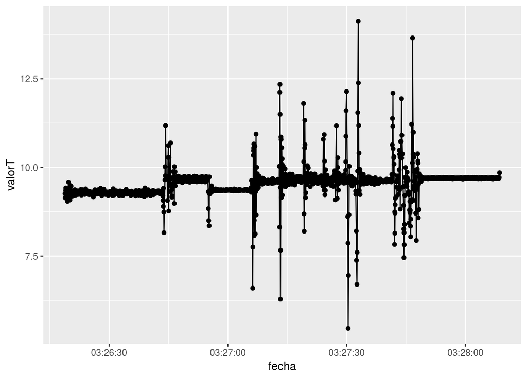

```r
library(ggplot2)
gt <- ggplot(XYZ, aes(fecha, valorT))
gt + geom_point() + geom_line()
```

```r
XYZ$minuto <- format(XYZ$fecha, "%M")
```

Procedimiento para calcular el tamaño de muestra

Insumos: - Datos de cinco (5) minutos de caminata por duplicado (2 veces) - Datos de viaje en bus por diez minutos por duplicado (2 veces)

En total se tiene dos series para caminatas y dos series para viaje en bus.

Dividir los datos de los 5 minutos de caminata por minuto, se obtienen así 10 tramos o divisiones, a cada división se calcula el promedio de la aceleración total de tal manera que se tienen 10 datos de promedio.

```r
library(dplyr)
XYZ$minuto <- factor(format(XYZ$fecha, "%M"))
promMin <- XYZ %>%
           select(valorT, minuto) %>%
           group_by(minuto) %>%
           summarise(promT = mean(valorT))
promMin
```

```
## # A tibble: 3 × 2
##   minuto    promT
##   <fctr>    <dbl>
## 1     26 9.389820
## 2     27 9.627906
## 3     28 9.702610
```

```r
sd(promMin$promT)
```

```
## [1] 0.163352
```

Se calcula el tamaño de muestra de la siguiente manera:

```r
library(pwr)
delta <- 0.17
sigma <- sd(promMin$promT)
d <- delta/sigma
result1 <- pwr.t.test(d = d, sig.level = 0.05, power = 0.80, type = 'two.sample')
result1
```

```
##
##      Two-sample t test power calculation
##
##               n = 15.51559
##               d = 1.040697
##       sig.level = 0.05
##           power = 0.8
##     alternative = two.sided
##
## NOTE: n is number in *each* group
```

En el ejemplo anterior se estima que la diferencia detectable es mayor que la desviación estándar en aproximadamente un 4.1 % aproximadamente.

```r
(delta-sigma)/sigma * 100
```

```
## [1] 4.069721
```

Por decisión del grupo se determina el nivel de porcentaje de error con respecto a la desviación estándar para relizar el experimento.

El procedimiento se repite para los datos del viaje en bus, pero esta vez se cada dos (2) minutos y de nuevo se tienen 10 (diez) datos en total.

Se debe examinar si la diferencia entre el promedio de los promedios de caminata y bus es mayor que el nivel de “d” propuesto en el tamaño de muestra.

## Tamaño de muestra final

Para el ejemplo se tiene que el número de persona por cada nivel es de 16

Las actividades son:

- Caminar.
- Correr o trotar.
- Viajar en bus.
- Viajar en metro.
- Un nivel propuesto por el grupo.
- Otro nivel propuesto por el grupo.

Se tienen seis niveles, por lo tanto el número de personas es de 16 x 6 = 96 personas diferentes, a cada persona se le toma como mínimo 5 minutos en la actividad respectiva.

Recordar registrar las siguientes variables por persona:

- Género.
- Estatura
- Peso.
- Edad (La población está determinada a edades entre [15 y 30] años)

Registar la posición en la que estaba cuando estaba en los medios de transporte.

- Posición: parado, sentado.
- Hora del día.
- Día de la semana.
- Clima: lluvia, no lluvia.